# La desigualdad de género se puede medir

Datos de la Encuesta Permanente de Hogares. 4to trimestre de 2018.

Julieta Moure[^1], Daiana Serpa[^2], Natsumi Shokida[^3] para Economía Femini(s)ta

Marzo de 2020

## Introducción

En este informe se presentan una serie de indicadores sociales, desagregados por sexo, calculados con bases públicas de la EPH (Encuesta Permanente de Hogares - INDEC - Argentina). El objetivo de esta presentación es visibilizar la desigualdad de género en la composición del mercado de trabajo, la percepción de ingresos, entre otras cuestiones, en un formato amigable.  
Quienes estén interesados en reproducir los cálculos necesarios para obtener la información que aquí se presenta, pueden descargar la sintaxis en lenguaje R.[^4]  
Todos los datos refieren a los 31 aglomerados urbanos relevados en la EPH y en esta ocasión corresponden al 4to trimestre 2018.

## Mercado de Trabajo

### Tasas básicas

En primer lugar se presentan algunos indicadores clásicos (utilizados a nivel internacional) que caracterizan la composición del mercado de trabajo, desagregados según el sexo.  
La tasa de Actividad es la relación entre aquellos que participan en el mercado de trabajo (ya sea como ocupados o como desocupados) y la población total. En este caso, dicha tasa es ampliamente mayor entre los varones (la diferencia supera los 20 puntos porcentuales).

Esta discrepancia podría ser explicada por múltiples causas. Una de ellas es que una importante porción de las mujeres en edad laboral dediquen su tiempo a realizar tareas domésticas no remuneradas, en lugar de tener una actividad en el mercado de trabajo. Otra razón posible podría ser el hecho de que las mujeres tiendan, en promedio, a educarse más que sus pares varones.

La tasa de Empleo, por su parte, exhibe la proporción de ocupados entre la población total. La diferencia entre varones y mujeres en este caso también supera los 20 puntos, denotando el mismo fenómeno anteriormente mencionado.

Es importante aclarar que, desagregando en función de ciertas variables (edad, nivel educativo, tenencia de hijos/as o nivel de ingresos), estas diferencias entre hombres y mujeres sufrirán variaciones.

**Figura 1.**

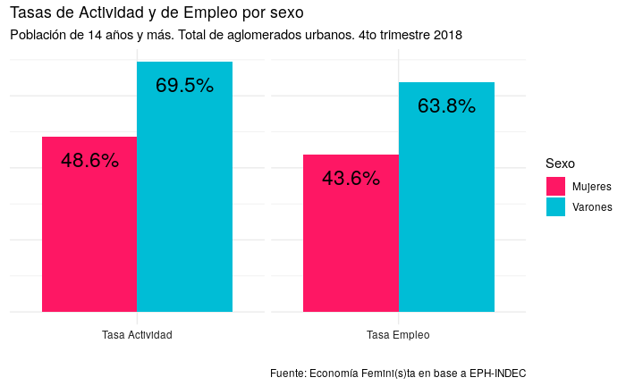

A diferencia de las tasas anteriores, las tasas de desocupación y subocupación expresan la proporción que estos grupos representan en la Población Económicamente Activa. En este caso, ambas tasas son mayores para las mujeres que para los varones. Esto señala que, incluso siendo minoría en el mercado de trabajo, las mujeres tendrían más dificultades para conseguir trabajo y/o para trabajar una jornada completa.

En su conjunto, estos cuatro indicadores presentan una primera imagen de la problemática que enfrentan las mujeres en el mercado de trabajo argentino.

**Figura 2.**

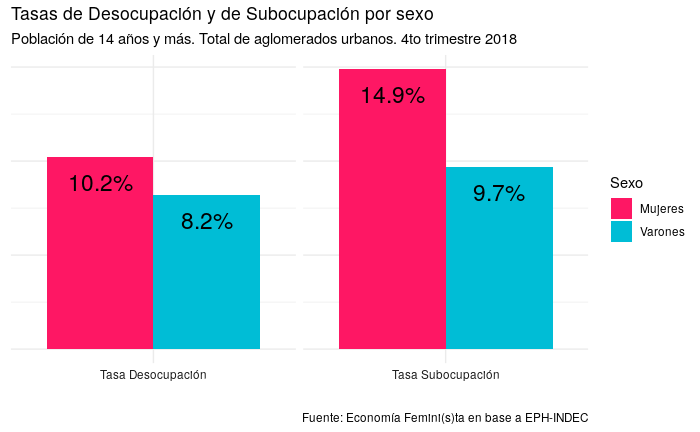

### Por grupos de edad y sexo

A continuación, se exponen las mismas tasas, pero desagregadas por grupos de edad además de por sexo.

Asimismo, se observa una sustancial diferencia en la tasa de actividad y empleo entre las mujeres y hombres de entre 30 y 64 años.

**Figura 3.**

**Principales Tasas del Mercado de Trabajo, por grupos de edad y sexo**

Población de 14 a 64 años. Total de aglomerados urbanos. 4to trimestre 2018

| Indicadores | de 14 a 29 años Mujeres | de 14 a 29 años Varones | de 30 a 64 años Mujeres | de 30 a 64 años Varones |
| --- | --- | --- | --- | --- |
| Tasa Actividad | 40.2% | 55.8% | 66.9% | 91.3% |
| Tasa Empleo | 31.6% | 47.2% | 62.4% | 86.4% |
| Tasa Desocupación | 21.4% | 15.4% | 6.8% | 5.4% |
| Tasa Subocupación | 15.0% | 11.5% | 15.1% | 9.2% |

Fuente: Economía Femini(s)ta en base a EPH-INDEC

## Empleo no registrado

La tasa de asalariados/as sin descuento jubilatorio es mayor en las mujeres. En concreto, Hay un 38.1% de las asalariadas que por su trabajo realizado no posee descuentos jubilatorios mientras que en los asalariados varones dicha tasa es del 32.9%

**Figura 4.**

**Empleo sin descuento jubilatorio por sexo**

Ocupadas/os asalariadas/os. Total de aglomerados urbanos. 4to trimestre 2018

| Sexo | Sin descuento jubilatorio |
| --- | --- |
| Mujeres | 38.1% |
| Varones | 32.9% |

Fuente: Economía Femini(s)ta en base a EPH-INDEC

## Acceso a Cargos jerárquicos

Además de tener una participación más restringida en el mercado de trabajo, las ocupadas encuentran más obstáculos para acceder a cargos jerárquicos: mientras que un 8.4% de los ocupados varones tienen cargos de dirección o son jefes, un 5.2% de las ocupadas ejercen puestos de esas características.

Esta problemática es conocida como Techo de Cristal, y hace referencia a la dificultad que poseen las mujeres para ascender profesionalmente en el mercado laboral.

**Figura 5.**

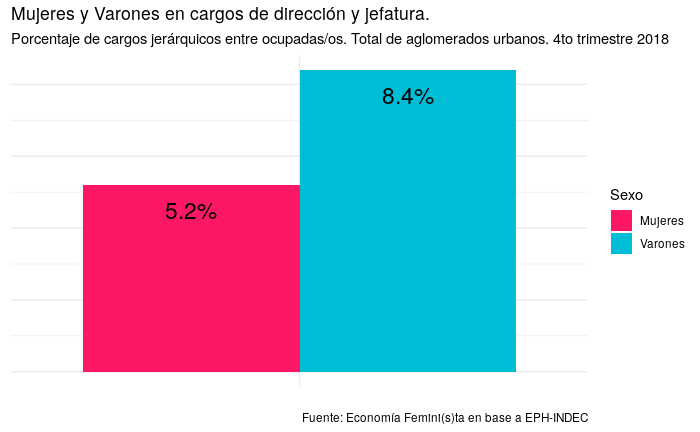

## Ramas de la ocupación

Como se observa en la siguiente tabla, las mujeres se encuentran sobrerrepresentadas en aquellos sectores (trabajo doméstico y enseñanza, entre otros) en los cuales el salario promedio es menor al de sectores más masculinizados (transporte y comunicación, por ejemplo).

Esto se conoce como Paredes de Cristal, y hace referencia a los muros invisibles que segmentan el desarrollo laboral de las mujeres y genera que estas se concentren en sectores menos dinámicos y peor remunerados.

**Figura 6.**

**Indicadores por ramas de la ocupación**

Tasa de feminización, ingreso mensual promedio, ingreso horario. Total de aglomerados urbanos. 4to trimestre 2018

| Rama de la ocupación | Tasa de feminización | Ingreso mensual promedio | Ingreso horario |
| --- | --- | --- | --- |
| Servicio domestico | 97.4% | $ 6.600 | $ 89 |
| Ensenanza | 73.5% | $18.400 | $183 |
| Servicios sociales y de salud | 66.6% | $24.600 | $174 |
| Otros servicios comunitarios, sociales y personales | 53.6% | $14.900 | $119 |
| Servicios financieros, de alquiler y empresariales | 45.6% | $23.900 | $159 |
| Hoteles y restaurantes | 44.6% | $13.500 | $ 83 |
| Administracion publica, defensa y seguridad social | 43.7% | $24.900 | $161 |
| Comercio | 40.4% | $16.500 | $ 96 |
| Industria manufacturera | 31.5% | $18.800 | $118 |
| Actividades no bien especificadas | 26.5% | $29.400 | $165 |
| Otras ramas | 18.8% | $23.600 | $135 |
| Actividades primarias | 16.3% | $39.600 | $238 |
| Transporte, almacenamiento y comunicaciones | 13.5% | $22.900 | $130 |
| Construccion | 3.2% | $15.500 | $ 99 |

Fuente: Economía Femini(s)ta en base a EPH-INDEC

## Brechas de ingresos mensuales

A continuación se hace foco en las diferencias de montos de ingresos que perciben los varones y las mujeres. Estos ingresos pueden provenir de diversas fuentes y al mismo tiempo pueden desagregarse según características adicionales de las personas o los puestos que desempeñan. Incluso pueden distinguirse los ingresos mensuales y los ingresos horarios.

Para dimensionar estas diferencias hacemos uso del concepto de “brecha”, que en este caso se calcula como la diferencia entre los ingresos promedios de los varones y las mujeres, expresada en términos del ingreso más alto. Es decir, que puede leerse como “las mujeres perciben ingresos que, en promedio, son un …% menores que los de los varones”.

Simultáneamente, en el mercado de trabajo, las mujeres ganan en promedio un 26.1% menos que los varones ($15.300 vs. $20.700 ). Estos datos corresponden a la totalidad de ocupadas/os, cualquiera sea su categoría ocupacional, calificación o jerarquía, y observando en este caso los ingresos provenientes de la ocupación principal.

Finalmente, si tomamos en cuenta a aquellas personas que no poseen descuentos jubilatorios, se observa como las mujeres ganan en promedio un 33.5% menos que sus pares. Es decir que la brecha de ingresos de las/os ocupadas/os se amplía cuando vemos a aquellas/os asalariadas/os que tienen peores condiciones de trabajo.

**Figura 7.**

**Brechas de ingresos mensuales**

Por poblaciones y tipos de ingresos. Total de aglomerados urbanos. 4to trimestre 2018

| Población | Ingreso | Brecha | Media del ingreso Mujeres | Media del ingreso Varones |
| --- | --- | --- | --- | --- |
| Perceptores de ingresos | Ingreso Total Individual | 30.1% | $15.200 | $21.800 |
| Ocupadas/os | Ingreso de la Ocupación Principal | 26.1% | $15.300 | $20.700 |
| Asalariadas/os sin desc. jubil. | Ingreso de la Ocupación Principal | 33.5% | $ 8.300 | $12.500 |
| Perceptores de jubilación | Jubilación | 12.3% | $11.900 | $13.600 |

Fuente: Economía Femini(s)ta en base a EPH-INDEC

### Brecha de ingresos mensuales por calificación del puesto de trabajo

El siguiente gráfico señala cómo la brecha de ingresos mensuales de las/os ocupadas/os se mantiene incluso a iguales niveles de calificación del puesto de trabajo. Por ejemplo, mientras que los varones que trabajan en ocupaciones profesionales tienen un ingreso medio de $42.100, las mujeres ocupadas en ese mismo segmento perciben un ingreso medio de $30.000, es decir, un 28.7% menos que los varones.  
En los puestos no calificados, los varones ganan $12.600 en promedio, al tiempo que las mujeres ganan alrededor de $8.200. Esta brecha es del 35.2%.

**Figura 8.**

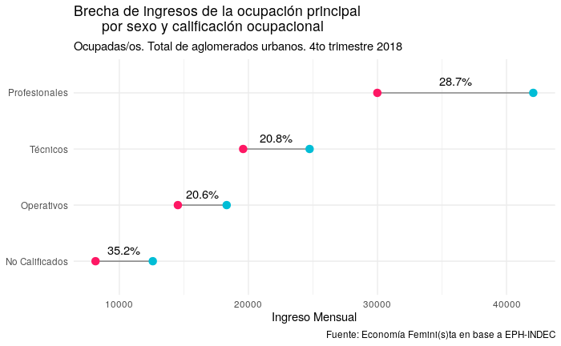

### Brecha de ingresos mensuales por nivel educativo

Como puede observarse en el cuadro siguiente, la proporción de ocupadas/os con nivel educativo superior es notablemente mayor en las mujeres que en los varones

**Figura 9.**

**Nivel educativo de mujeres y varones**

Porcentaje por columnas. Ocupadas/os. Total de aglomerados urbanos. 4to trimestre 2018

| Nivel Educativo | Mujeres | Varones |
| --- | --- | --- |
| Sin Instrucción | 3.0% | 4.5% |
| Primaria | 23.3% | 34.7% |
| Secundaria | 42.0% | 42.7% |
| Superior | 31.8% | 18.1% |

Fuente: Economía Femini(s)ta en base a EPH-INDEC

Sin embargo, a igual nivel educativo, los ingresos laborales de las mujeres trabajadoras son inferiores a los de los varones. Esta diferencia de ingresos es del 29.1% para las de nivel universitario/superior, y del 41.0% para las que cuentan con nivel primario.

**Figura 10.**

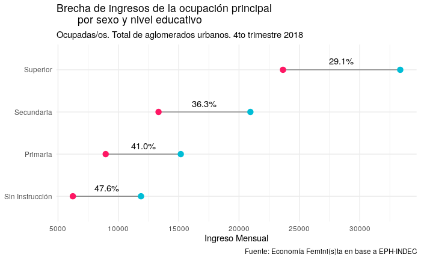